# about – Microbial Genomics Lab | Department of Microbiology, Panjab University Chandigarh

## About Our Lab

Our research lab leads cutting-edge investigations in microbial genomics, transcriptomics, fungal pathogenesis, and the human microbiome. We focus on clinically significant pathogens like *Candida* spp. and mucormycosis-causing fungi, integrating wet lab (*in vitro* and *in vivo*) experimentation—including antifungal screening and nanoparticle synthesis, with robust in-house multi-omics data analysis.

We explore antimicrobial resistance, host-pathogen interactions, and microbial pathogenesis using advanced tools in molecular biology and bioinformatics. The lab features a high-performance Linux-based genome analysis workstation running pipelines for genomics, transcriptomics, and metagenomics.

Our team brings expertise in large-scale omics data analysis and visualization, using R and Python to decode complex biological systems and their relevance to human health. This includes investigations into immune-mediated disorders such as Kawasaki disease, where integrative multi-omics profiling provides comprehensive insights into disease pathophysiology and host immune responses.

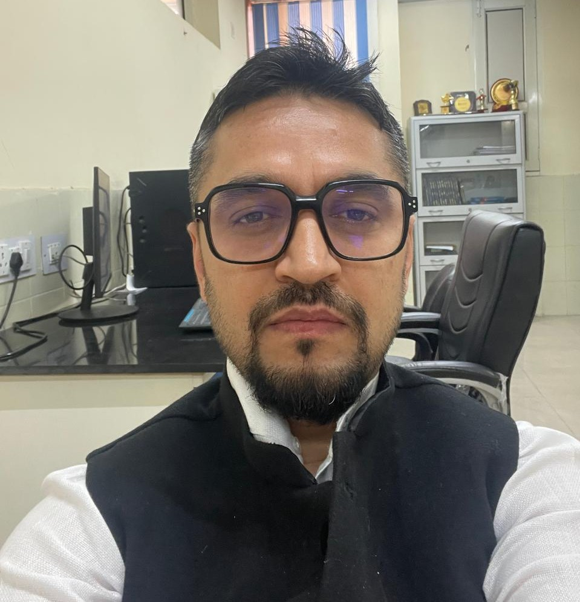

### Dr. Khem Raj

Dr. Khem Raj is an expert in microbial genomics, transcriptomics, and fungal pathogenesis. His research focuses on microbial-host interactions and antimicrobial resistance, combining experimental biology with integrative omics approaches. He specializes in data-driven insights using R and Python to explore complex host-pathogen dynamics. Under his leadership, the lab bridges molecular microbiology and computational biology to drive translational research on emerging pathogens.

## Research Scholars

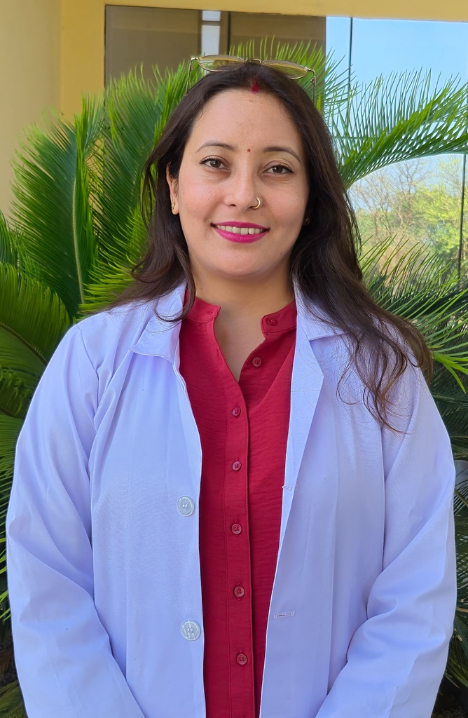

### Preeti Negi

Research on green synthesis of silver nanoparticles using *Trillium govanianum* and their application in studying *Candida auris* pathogenesis. Combines principles of nanotechnology and computational docking to explore novel antifungal strategies.

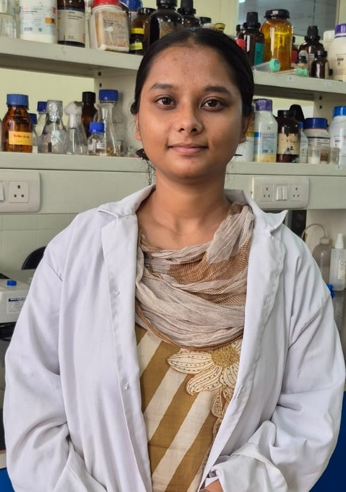

### Gurkeerat Kaur

Conducted research on the antifungal and antibiofilm activities of green-synthesized silver-graphene nanohybrids against multidrug-resistant *Candida auris*, encompassing synthesis, characterization, and comprehensive biological evaluations.

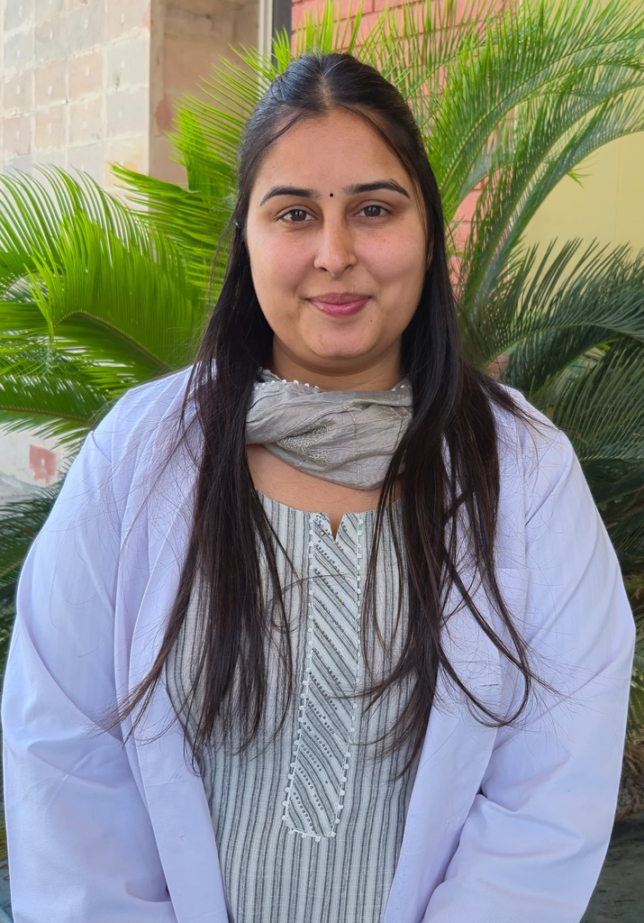

### Milani Sharma

Microbiome–immune interactions in Kawasaki disease, with emphasis on understanding how microbial community alterations influence immune dysregulation and inflammation.

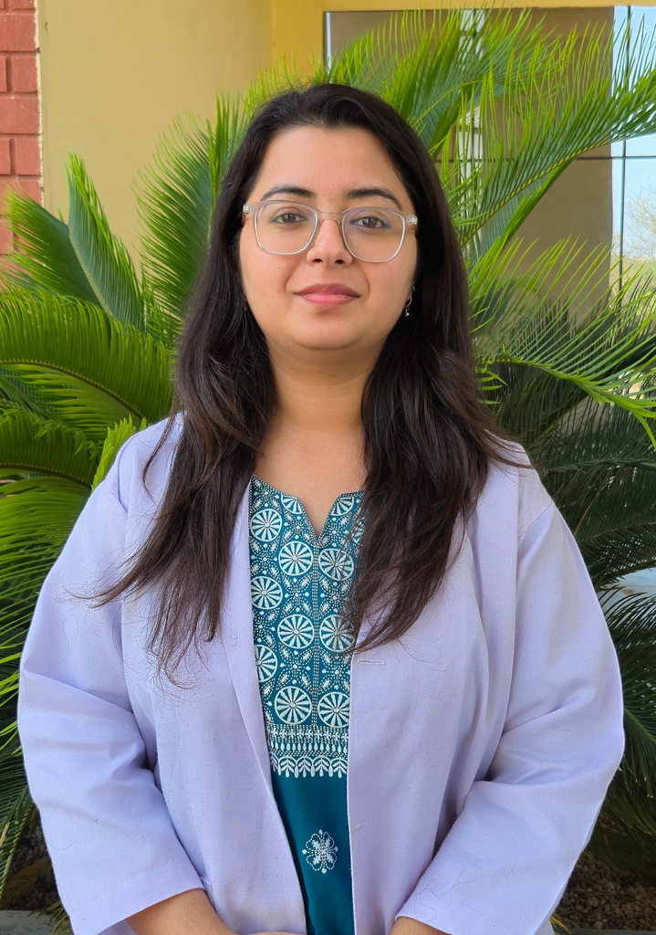

### Kanika Multani

Genomic and transcriptomic analysis of mucormycosis using high-throughput sequencing and RNA-Seq workflows. Applies computational genomics to study fungal pathogens.

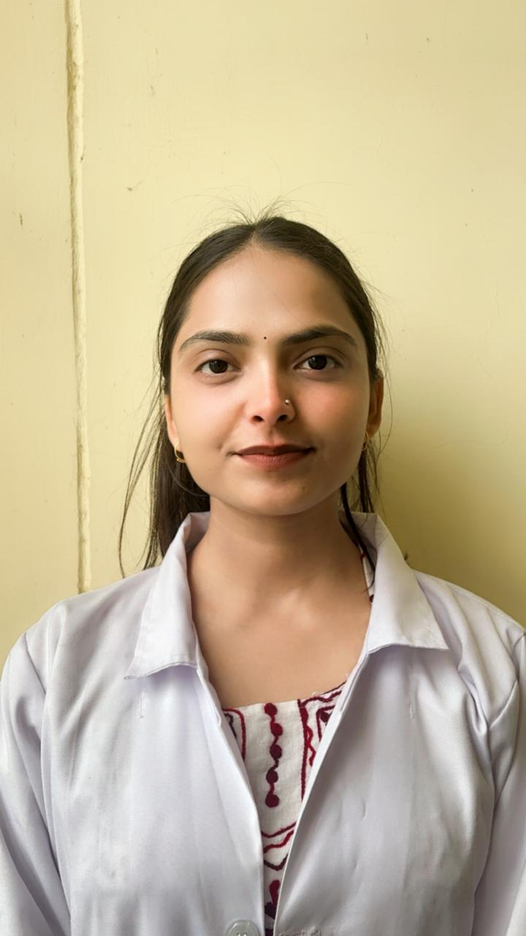

### Neha Kumari

Research focuses on antimicrobial resistance and its mechanisms in *Candida tropicalis*, including its activity, mode of action, and therapeutic potential. Integrates molecular and computational approaches to understand pathogen interactions and support antifungal drug development.

## M.Sc. Students

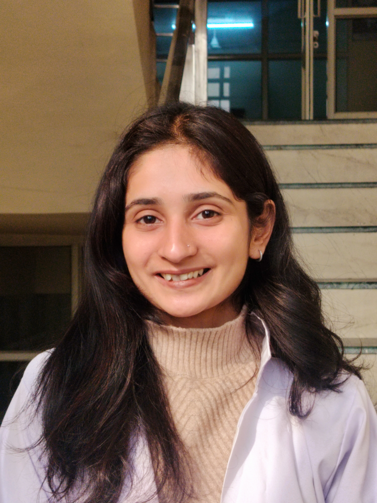

### Anshika Thakur

Design and evaluation of antifungal peptides against *Candida tropicalis*, with emphasis on MIC determination, antifungal efficacy, and peptide–pathogen interactions.

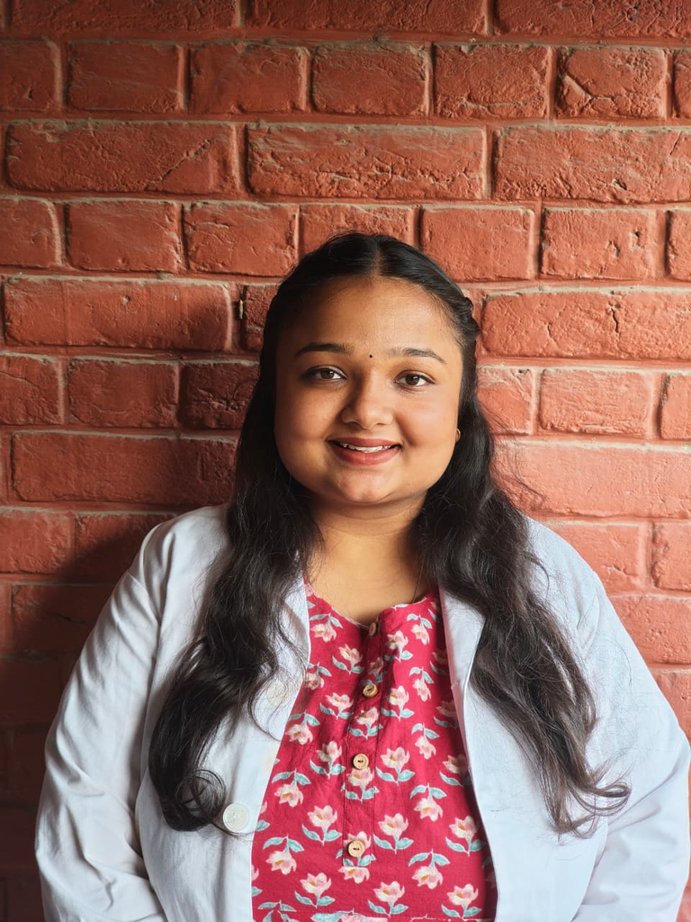

### Ojal

Engaged in research on antifungal peptides against *Candida auris*, involving computational screening, peptide characterization, and analysis of antifungal activity to address multidrug resistance.

[figure not shown]

### Pratibha Kaushik

Single-Cell Genomic and Transcriptomic Profiling of Pulmonary Mucormycosis: A Computational Analysis of Immune Dysregulation in BAL and Peripheral Blood.

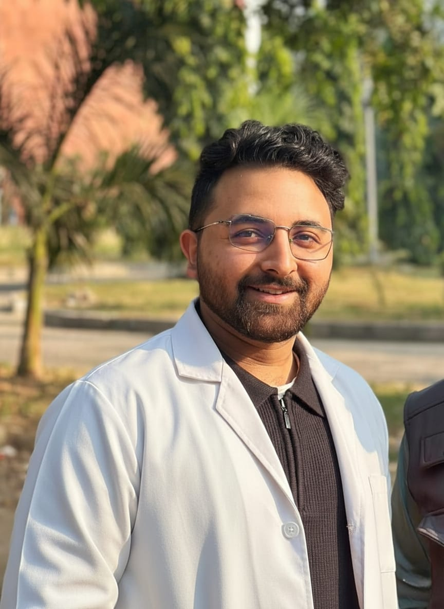

### Aryan Bhan

Working on transcriptional changes in neutrophils during COVID-19 infection, with a strong focus on bulk RNA-Seq data analysis workflows and genomic workflows.

## Collaborators

### Dr. Manpreet Dhaliwal

**Advanced Paediatric Centre**  
Postgraduate Institute of Medical Education and Research

### Dr. Rakesh Kumar Pilania

**Department of Medical Microbiology**  
Postgraduate Institute of Medical Education and Research

## Research Projects

### Ongoing Projects

1. **Whole Genome Sequencing of *Mycobacterium leprae* Clinical Strains for Determining Drug Resistance and Strain lineage in India: - A multicentre prospective study**  
   **Role:** Co-Investigator  
   **Funding Agency:** ICMR  
   **Funding Amount:** INR 2.9 Crore
2. **To discover novel genetic variants predisposing to Inborn Errors of Immunity in pediatric and adult mucormycosis patients**  
   **Role:** Co-Investigator  
   **Funding Agency:** Indian Council of Medical Research (ICMR), New Delhi  
   **Funding Amount:** INR 57.34 Lakhs

### Sanctioned Projects

1. **Identification and validation of monocyte-expressed core hub genes underlying the development of coronary artery abnormalities in Kawasaki disease: a multi-centric collaborative study using a high-throughput RNA-sequencing approach**  
   **Role:** Co-Investigator  
   **Funding Agency:** DBT-BIRAC  
   **Funding Amount:** INR 2.4 Crore
2. **Exploring IVIg Resistance in Kawasaki Disease: Investigating Unresponsiveness to IVIg through Bulk and Single-cell RNA Sequencing Technologies**  
   **Role:** Co-Investigator  
   **Funding Agency:** ICMR  
   **Funding Amount:** INR 1,10,67,305
3. **Exploring Neutrophil Lineages in Kawasaki Disease: Immunophenotyping and Transcriptomic Insights for Targeted Therapies**  
   **Role:** Co-Investigator  
   **Funding Agency:** ICMR  
   **Funding Amount:** INR 1,00,46,305
4. **Unveiling Host Genetic Susceptibility to Mucormycosis in the Indian Population Using Genome India Project and Clinical Exome Data**  
   **Role:** Principal Investigator  
   **Funding Agency:** DBT  
   **Funding Amount:** INR 22,71,600

### Completed Projects

1. **Deciphering the microbiome landscape of native and migrated ‘Pangwala’ tribal population of India**  
   **Role:** Principal Investigator  
   **Funding Agency:** Department of Health Research, Govt. of India (File No. R.12020/13/2018-HR)  
   **Funding Amount:** INR 28.26 lakhs
2. **A transcriptome-based study to evaluate the pathways associated with immune dysfunction in COVID-19 Associated Mucormycosis**  
   **Role:** Co-Investigator  
   **Funding Agency:** Pfizer, Fungal Infections Study Forum (FISF)  
   **Funding Amount:** INR 17 lakhs

## Publications

1. Negi, P., Verma, N., Rishi, P., Multani, K., Sharma, M., Kumari, S., & Raj, K. (2026). *Candida auris*: A multidimensional focus on its identification, epidemiology, pathogenesis, and therapeutic options. *Archives of Microbiology*. [DOI](https://doi.org/10.1007/s00203-026-04864-z)
2. Patial, S., Raj, K., & Shukla, G. (2026). Modulation of gut-heart axis by synbiotic (*Lactiplantibacillus plantarum* M10 and Isomaltose) in high cholesterol diet induced atherosclerotic murine model. *BMC Microbiology*, 26(1), 279. [DOI](https://doi.org/10.1186/s12866-026-04840-z)
3. Sihag, S., Kaur, G., Sharma, S., Dasgupta, A., Raj, K., & Kaur, R. (2025). Antimicrobial and Anticancer Potential of *Chitinophaga* sp. S167 Mediated Synthesis of Silver Nanoparticles. *ChemistrySelect*, 10(21), e00768. [DOI](https://doi.org/10.1002/slct.202500768)
4. Vijeata, A., Ghawri, H., Chaudhary, G. R., Raj, K., & Chaudhary, S. (2025). Engineering fungicidal nitrogen-doped carbon dots from *Trillium govanianum* rhizomes: A theoretical and experimental approach against *Candida auris*. *Applied Surface Science*, 709, 163789. [DOI](https://doi.org/10.1016/j.apsusc.2025.163789)
5. Patial, S., Sharma, A., Raj, K., & Shukla, G. (2025). Selection and potential of cholesterol-lowering indigenous probiotic: insights from in vitro and in vivo study. *Scientific Reports*, 15(1), 38051.
6. Dhaliwal, M., Muthu, V., Sharma, A., Raj, K., Rudramurthy, S. M., Agarwal, R., & Chakrabarti, A. (2024). Immune and metabolic perturbations in COVID‐19‐associated pulmonary mucormycosis: A transcriptome analysis of innate immune cells. *Mycoses*, 67(1), e13679. [DOI](https://doi.org/10.1111/myc.13679)
7. Negi, P., Chadha, J., Harjai, K., Gondil, V. S., Kumari, S., & Raj, K. (2024). Antimicrobial and Antibiofilm Potential of Green-Synthesized Graphene–Silver Nanocomposite against Multidrug-Resistant Nosocomial Pathogens. *Biomedicines*, 12(5), 1104. [DOI](https://doi.org/10.3390/biomedicines12051104)
8. Patial, S., Sharma, A., Raj, K., & Shukla, G. (2024). Atherosclerosis: Progression, risk factors, diagnosis, treatment, probiotics and synbiotics as a new prophylactic hope. *The Microbe*, 5, 100212. [DOI](https://doi.org/10.1016/j.microb.2024.100212)
9. Raj, K., Paul, D., Rishi, P., Shukla, G., Dhotre, D., & YogeshSouche. (2024). Decoding the role of oxidative stress resistance and alternative carbon substrate assimilation in the mature biofilm growth mode of *Candida glabrata*. *BMC Microbiology*, 24(1), 128. [DOI](https://doi.org/10.1186/s12866-024-03274-9)
10. Verma, N., Riyaz, M., Kaur, G., Negi, P., Ghawri, H., & Raj, K. (2024). Anticandidal Efficacy of Green Synthesized Silver Nanoparticles Using Trans-Himalayan Plant Extracts Against Drug Resistant Clinical Isolates of *Candida auris*. *Indian Journal of Microbiology*, 64(4), 1912-1928. [DOI](https://doi.org/10.1007/s12088-024-01277-8)
11. Sharma, A., Ramniwas, S., Kumar, G., & Raj, K. (2024). Host–pathogen interaction between the African fig fly, *Zaprionus indianus*, and its external mycobiome under laboratory conditions. *Entomologia Experimentalis et Applicata*, 172(9), 863-872.
12. Riyaz, M., & Raj, K. (2023). Emerging Microbial Identification Technologies in the Era of OMICS and Genome Editing. In R. C. Sobti, R. C. Kuhad, R. Lal, & P. Rishi (Eds.), *Role of Microbes in Sustainable Development: Human Health and Diseases* (pp. 37-63). Springer Nature. [DOI](https://doi.org/10.1007/978-981-99-3126-2_2)
13. Sharma, S., Raj, K., Riyaz, M., & Singh, D. D. (2023). Antimicrobial Studies on Garlic Lectin. *Probiotics & Antimicrobial Proteins*, 15(6), 1501-1512. [DOI](https://doi.org/10.1007/s12602-022-10001-1)
14. Raj, K., Rishi, P., Shukla, G., Rudramurhty, S. M., Mongad, D. S., & Kaur, A. (2022). Possible Contribution of Alternative Transcript Isoforms in Mature Biofilm Growth Phase of *Candida glabrata*. *Indian Journal of Microbiology*, 62(4), 583-601. [DOI](https://doi.org/10.1007/s12088-022-01036-7)
15. Kaur, U. J., Chopra, A., Preet, S., Raj, K., Kondepudi, K. K., Gupta, V., & Rishi, P. (2021). Potential of 1-(1-napthylmethyl)-piperazine, an efflux pump inhibitor against cadmium-induced multidrug resistance in *Salmonella enterica* serovar Typhi as an adjunct to antibiotics. *Brazilian Journal of Microbiology*, 52(3), 1303-1313. [DOI](https://doi.org/10.1007/s42770-021-00492-5)
16. Rishi, P., Thakur, K., Vij, S., Rishi, L., Singh, A., Kaur, I. P., Patel, S. K. S., Lee, J. K., & Kalia, V. C. (2020). Diet, Gut Microbiota and COVID-19. *Indian Journal of Microbiology*, 60(4), 420-429. [DOI](https://doi.org/10.1007/s12088-020-00908-0)
17. Sarkar, S., Rastogi, M., Chaudhary, P., Kumar, R., Arora, P., Sagar, V., Sahni, I. S., Shethi, S., Thakur, K., Ailawadhi, S., Toor, D., & Chakraborti, A. (2017). Association of rheumatic fever & rheumatic heart disease with plausible early & late-stage disease markers. *Indian Journal of Medical Research*, 145(6), 758-766. [DOI](https://doi.org/10.4103/ijmr.IJMR_1554_14)

## News and Events

Our laboratory is part of a collaborative project under the ICMR Centre for Advanced Research (CAR) titled “Kawasaki Disease: From Discovery to Delivery – Safeguarding Indian Children from Acquired Heart Disease (The CARe-KD Initiative),” sanctioned to the Advanced Paediatrics Centre (APC), PGIMER, Chandigarh.

Our lab has been awarded an ICMR research grant to advance investigations into mucormycosis, strengthening our efforts in combating this life-threatening fungal infection.

Postgraduate students and research scholars secured 1st and 2nd prizes at the International Conference “Microgen Futuristica-2026: Microbial Innovations – Local Challenges, Global Solutions,” highlighting their outstanding contributions to microbiological research.

Travel award by ISHAM (International Society for Human and Animal Mycology) to present research work at ISMM, Chennai, 2025.

Our lab presented research at the 15th National Biennial Conference of the Indian Society of Medical Mycologists, showcasing advancements in fungal disease diagnostics and therapeutics.

Lab members also presented their latest findings at the Computational Biology Conference 2025, highlighting the integration of bioinformatics tools in infectious disease studies.

## Join Us

Opportunities in microbiology, molecular biology and bioinformatics.

Email: khemrajthakur@gmail.com

## Contact Us

Department of Microbiology  
Basic Medical Sciences Block I, South Campus  
Panjab University, Sector-25, Chandigarh-160014, India

Email: khemrajthakur@pu.ac.in  
Mobile: +91 9876726053  
[View on Google Maps](https://maps.google.com)